# 美国经济

## 就业和物价

### 就业人口

#### 就业人口长期数据

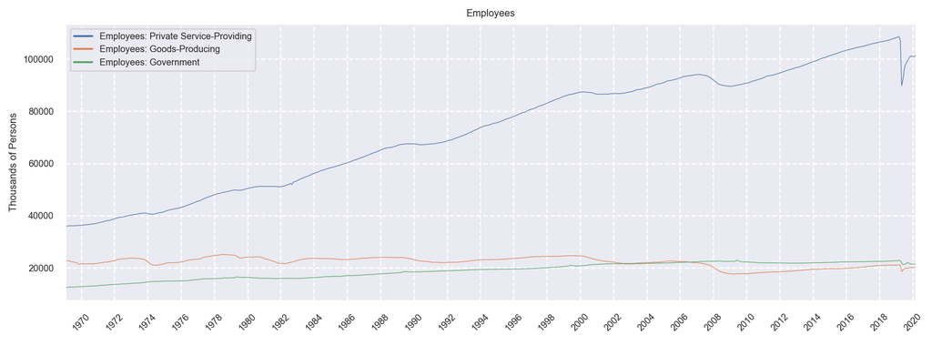

#### 就业人口长期变化趋势

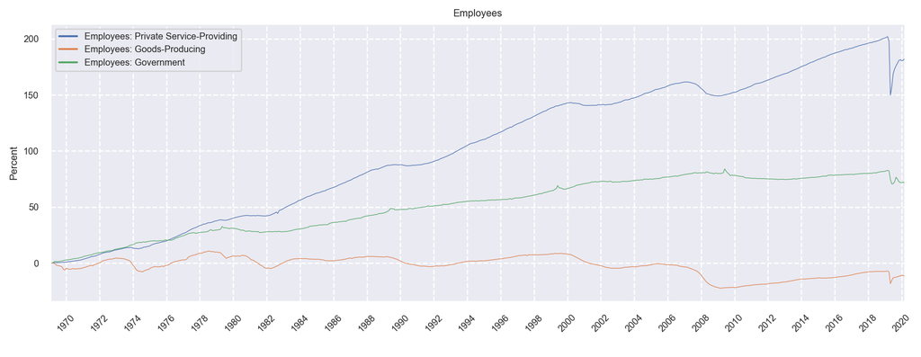

#### 就业人口中期变化趋势

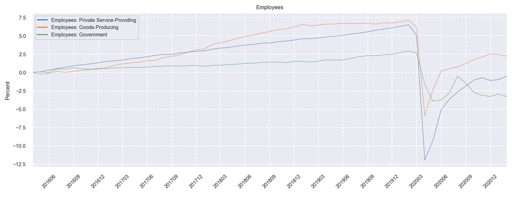

### 个人消费支出和通胀预期

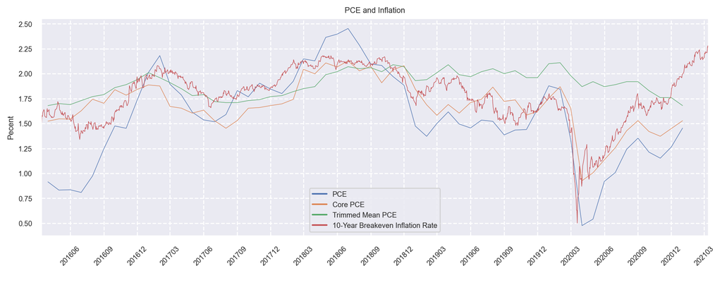

- [Measuring inflation trends: Why use different inflation measures for policy analysis?](https://fredblog.stlouisfed.org/2018/05/measuring-inflation-trends/) Congress has instructed the Federal Reserve to pursue monetary policies that promote maximum employment and price stability. The Federal Open Market Committee (FOMC) has determined that “inflation at the rate of 2 percent, as measured by the annual change in the price index for personal consumption expenditures [PCE], is most consistent over the longer run with the Federal Reserve’s statutory mandate” for price stability.

## 国民生产总值和M2货币

### GDP与M2长期总量

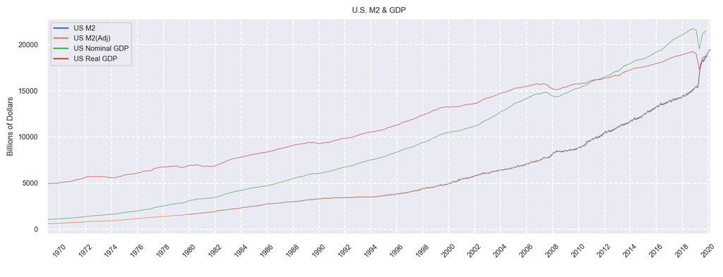

#### 相关性

|  | US M2 | US M2(Adj) | US Nominal GDP | US Real GDP |
| --- | --- | --- | --- | --- |
| US M2 | 1.000000 | 0.999923 | 0.982282 | 0.954126 |
| US M2(Adj) | 0.999923 | 1.000000 | 0.971949 | 0.940680 |
| US Nominal GDP | 0.982282 | 0.971949 | 1.000000 | 0.992898 |
| US Real GDP | 0.954126 | 0.940680 | 0.992898 | 1.000000 |

**M2 Money Stock**

The non-seasonally adjusted version of this weekly series: https://fred.stlouisfed.org/series/WM2NS

https://fred.stlouisfed.org/series/M2SL

**Gross Domestic Product**

Gross domestic product (GDP), the featured measure of U.S. output, is the market value of the goods and services produced by labor and property located in the United States. https://fred.stlouisfed.org/series/GDP

**Real Gross Domestic Product**

Real gross domestic product is the inflation adjusted value of the goods and services produced by labor and property located in the United States.

[Is nominal GDP always higher than real GDP?](https://www.enotes.com/homework-help/nominal-gdp-always-higher-than-real-gdp-646666)

### GDP与M2中期总量

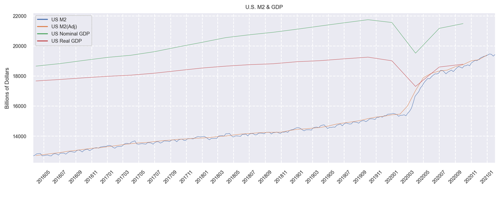

### M2与GDP占比

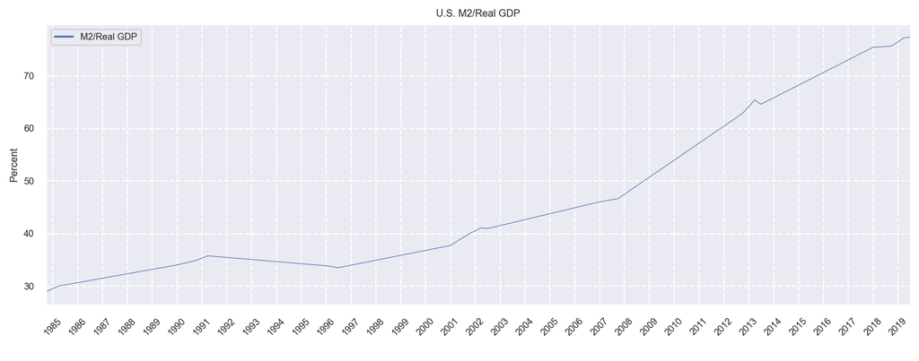

## 通胀和利率

### 通胀与利率长期关系

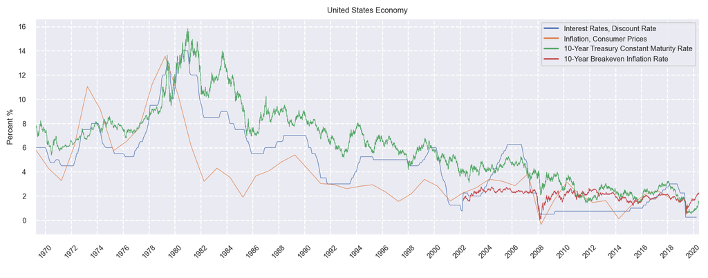

#### 相关性

|  | Interest Rates, Discount Rate | Inflation, Consumer Prices | 10-Year Treasury Constant Maturity Rate | 10-Year Breakeven Inflation Rate |
| --- | --- | --- | --- | --- |
| Interest Rates, Discount Rate | 1.000000 | 0.750958 | 0.912987 | 0.493290 |
| Inflation, Consumer Prices | 0.750958 | 1.000000 | NaN | NaN |
| 10-Year Treasury Constant Maturity Rate | 0.912987 | NaN | 1.000000 | 0.564638 |
| 10-Year Breakeven Inflation Rate | 0.493290 | NaN | 0.564638 | 1.000000 |

### 通胀与利率短期趋势

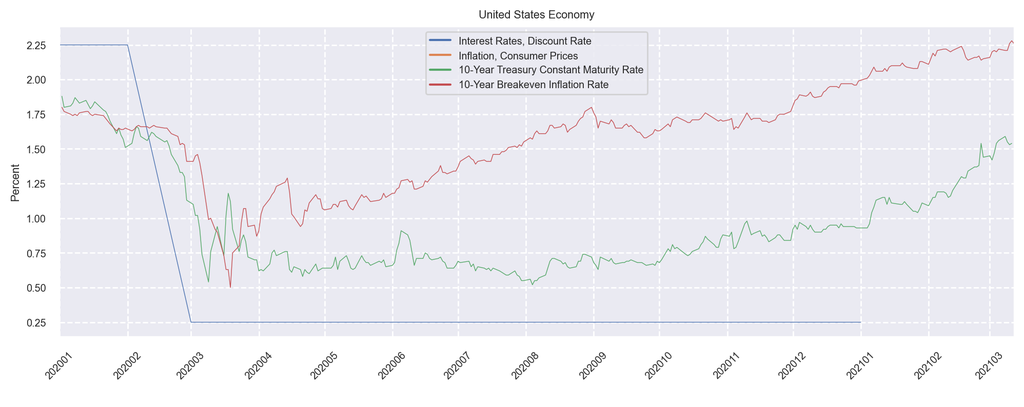

**Inflation, consumer prices for the United States**

Inflation as measured by the consumer price index reflects the annual percentage change in the cost to the average consumer of acquiring a basket of goods and services that may be fixed or changed at specified intervals, such as yearly. The Laspeyres formula is generally used.

International Monetary Fund, International Financial Statistics and data files.

**10-Year Breakeven Inflation Rate**

The breakeven inflation rate represents a measure of **expected inflation** derived from 10-Year Treasury Constant Maturity Securities (BC_10YEAR) and 10-Year Treasury Inflation-Indexed Constant Maturity Securities (TC_10YEAR). The latest value implies what market participants expect inflation to be in the next 10 years, on average. Starting with the update on June 21, 2019, the Treasury bond data used in calculating interest rate spreads is obtained directly from the U.S. Treasury Department.

### M2变化与通胀预期

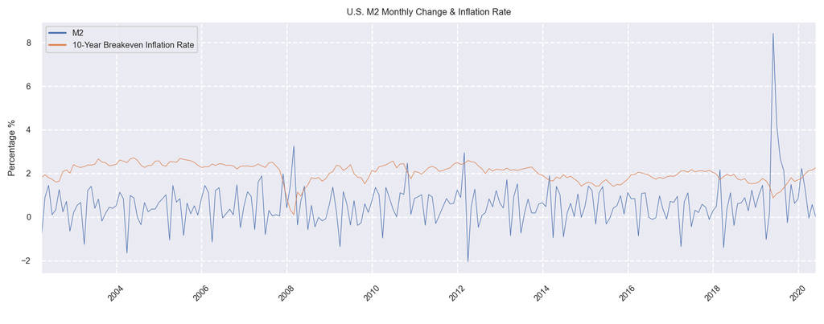

|  | M2 | 10-Year Breakeven Inflation Rate |
| --- | --- | --- |
| M2 | 1.000000 | -0.277112 |
| 10-Year Breakeven Inflation Rate | -0.277112 | 1.000000 |

## 股票市场

### 标普500与GDP

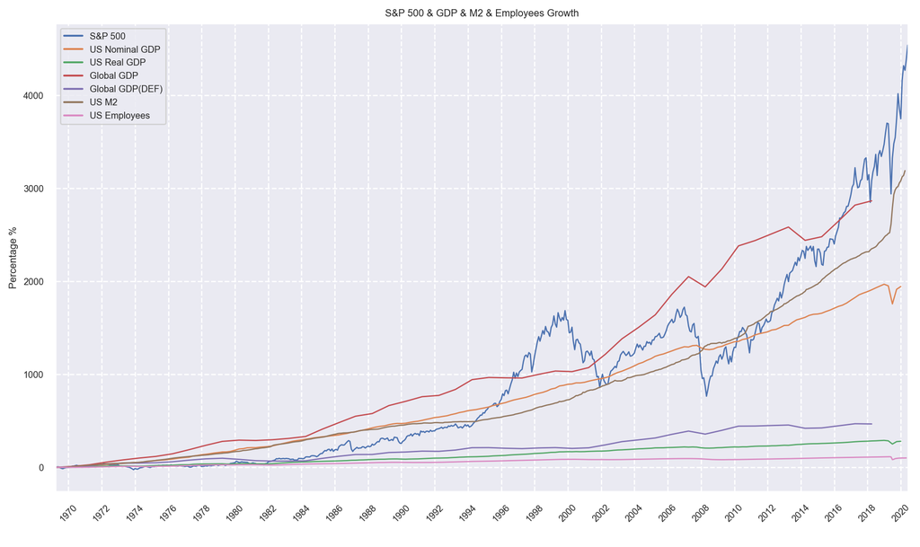

|  | S&P 500 | US Nominal GDP | US Real GDP | Global GDP | Global GDP(DEF) | US M2 | US Employees |
| --- | --- | --- | --- | --- | --- | --- | --- |
| S&P 500 | 1.000000 | 0.950180 | 0.929545 | 0.924584 | 0.902277 | 0.962796 | 0.864763 |
| US Nominal GDP | 0.950180 | 1.000000 | 0.992898 | 0.988825 | 0.982888 | 0.971949 | 0.945412 |
| US Real GDP | 0.929545 | 0.992898 | 1.000000 | 0.972168 | 0.974881 | 0.940680 | 0.973705 |
| Global GDP | 0.924584 | 0.988825 | 0.972168 | 1.000000 | 0.994304 | 0.982619 | 0.908077 |
| Global GDP(DEF) | 0.902277 | 0.982888 | 0.974881 | 0.994304 | 1.000000 | 0.962260 | 0.924296 |
| US M2 | 0.962796 | 0.971949 | 0.940680 | 0.982619 | 0.962260 | 1.000000 | 0.858806 |
| US Employees | 0.864763 | 0.945412 | 0.973705 | 0.908077 | 0.924296 | 0.858806 | 1.000000 |

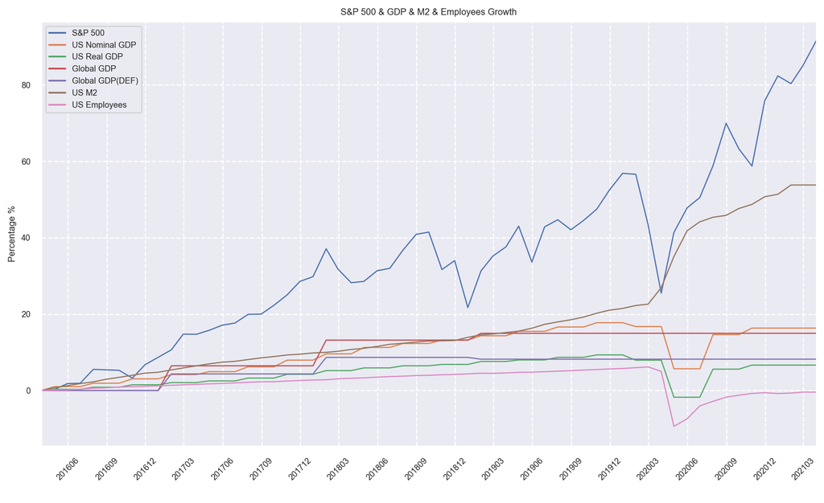

### 资产指数与GDP、M2

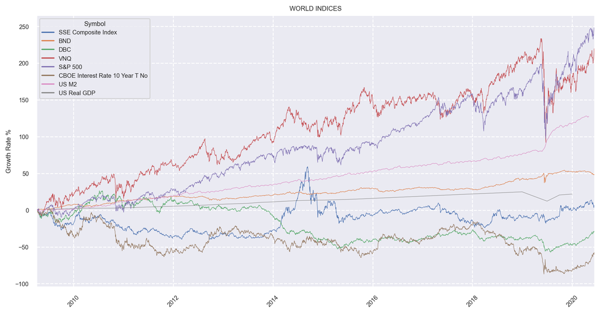

#### 资产价格相关性

| Symbol | SSE Composite Index | BND | DBC | VNQ | S&P 500 | CBOE Interest Rate 10 Year T No | US M2 | US Real GDP |
| --- | --- | --- | --- | --- | --- | --- | --- | --- |
| SSE Composite Index | 1.000000 | 0.387095 | -0.642117 | 0.452554 | 0.462959 | -0.127156 | 0.427847 | 0.345275 |
| BND | 0.387095 | 1.000000 | -0.759168 | 0.913506 | 0.940157 | -0.719138 | 0.976005 | 0.866672 |
| DBC | -0.642117 | -0.759168 | 1.000000 | -0.813440 | -0.770824 | 0.406417 | -0.798826 | -0.753835 |
| VNQ | 0.452554 | 0.913506 | -0.813440 | 1.000000 | 0.944660 | -0.494678 | 0.899239 | 0.978136 |
| S&P 500 | 0.462959 | 0.940157 | -0.770824 | 0.944660 | 1.000000 | -0.460710 | 0.966967 | 0.961112 |
| CBOE Interest Rate 10 Year T No | -0.127156 | -0.719138 | 0.406417 | -0.494678 | -0.460710 | 1.000000 | -0.599833 | -0.527797 |
| US M2 | 0.427847 | 0.976005 | -0.798826 | 0.899239 | 0.966967 | -0.599833 | 1.000000 | 0.998921 |
| US Real GDP | 0.345275 | 0.866672 | -0.753835 | 0.978136 | 0.961112 | -0.527797 | 0.998921 | 1.000000 |

### 标普500和通胀预期

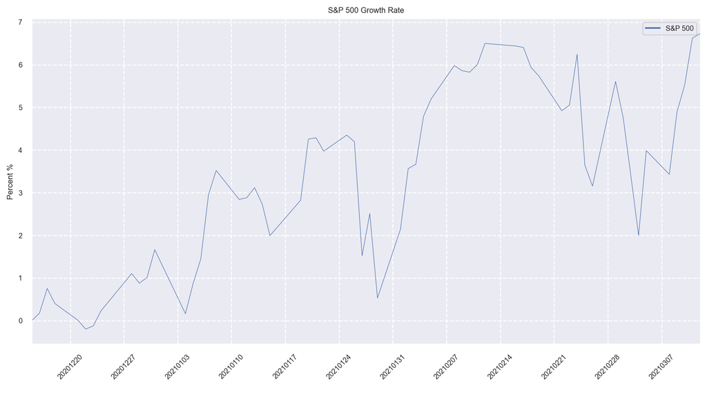

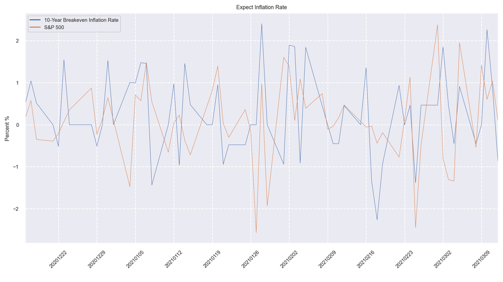

#### 标普500和通胀预期短期相关性

|  | 10-Year Breakeven Inflation Rate | S&P 500 |
| --- | --- | --- |
| 10-Year Breakeven Inflation Rate | 1.000000 | 0.232709 |
| S&P 500 | 0.232709 | 1.000000 |